# Python para Backend: web server con Fast API.

Nosotros podemos crear nuestro servidor con Python que provea servicios de datos de productos.

Vamos a usar una librería.

## [FAST API](https://fastapi.tiangolo.com/#installation)

Vamos a la parte de instalación y nos mostrará que necesitamos 2 dependencias

1. Fast API:
2. Uvicorn:

Uvicorn es un servidor web. Uvicorn va a mantener el servidor web y va a mandarlo online, todo lo que hayamos construido en Fast API. Así que este servidor lo va a publicar como un servidor web.

Así que vamos a cambiar a web-server.

```
#desactivar el entorno
deactivate
conda deactivate
#cambiar a el directorio
cd web-server
#activar el entorno
source env/bin/activate
#instalar las 2 dependencias
pip3 install fastapi
pip3 install uvicorn
#version mas reciente
pip3 install "fastapi[standard]"
#verificar que quede instalado
pip3 freeze
#actualizar requirements
pip3 freeze > requirements.txt
```

## Usando FAST API

Para poder probar las librerías vamos al archivo main.py y procedemos a modificarlo.

Añadimos el código:

```
from fastapi import FastAPI

#creando una instancia
app = FastAPI()

#sintaxis de decorador
@app.get("/")
def get_list():
    return [1,2,3]

#Creando otra ruta
@app.get("/contact")
def get_list():
    return {name: 'Dens'}
```

Ahora veremos como lanzar el servidor haciendo uso de uvicorn, en terminal:

```
uvicorn main:app --reload
```

Verificamos la salida, nos arroja la siguiente salida:

```
INFO:     Will watch for changes in these directories: ['/home/dens/Dens/Codes/Python_PIP/codes/py-project/web-server']
INFO:     Uvicorn running on http://127.0.0.1:8000 (Press CTRL+C to quit)
INFO:     Started reloader process [184701] using StatReload
INFO:     Started server process [184704]
INFO:     Waiting for application startup.
INFO:     Application startup complete.
```

[figure not shown]

Vamos a nuestro navegador web y colocamos en la barra de búsqueda:

`localhost:8000`

Obteniendo la salida

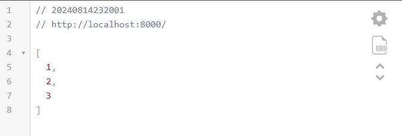

Vamos a nuestro navegador web y colocamos en la barra de búsqueda:

`localhost:8000/contact`

Obteniendo la salida

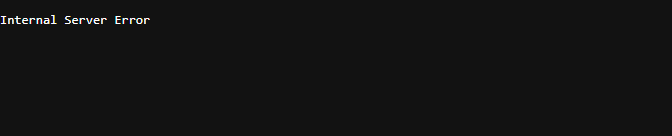

Vamos a ver que sucede.

### Revisando el error en la terminal

[figure not shown]

`name` no está definido, tenemos que encerrar `name` entre comillas, para que lo reconozca como un string y no como una variable.

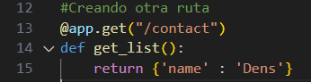

Una vez que se ha modificado el error, regresamos a la terminal y vemos que el servidor se actualiza solo, por lo que nos arroja las lineas:

[figure not shown]

Ahora regresemos al navegador y recarguemos:

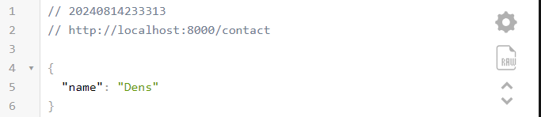

Listo!! Obtenemos la respuesta.

Hay otra cosa interesante que se puede hacer con Fast API. Esta pensado para devolver datos dentro de una estructura o recordemos que devuelve array como en el primer caso de los números, pero también tiene una forma de devolver HTML para construir páginas dinámicas.

## [HTML Response](https://fastapi.tiangolo.com/advanced/custom-response/#return-an-htmlresponse-directly)

En la documentación nos dice como devolver HTML, vamos a implementarlo en el archivo main.py

Añadimos el siguiente código:

```
from fastapi.responses import HTMLResponse

#Creando otra ruta
@app.get("/html",response_class=HTMLResponse)
def get_list():
    #Aquí puedo incluir el renderizado de una pagina
    return """
        <h1>Encabezado 1 para pagina</h1>
        <p>Este es un parrafo para la pagina</p>
    """
#Guardamos y automáticamente tiene que recargar
```

Una vez que lo modificamos guardamos los cambios y vamos a la siguiente dirección en el navegador: `http://127.0.0.1:8000/html` o `localhost:8000/html`.

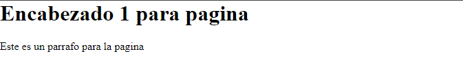

Listo!! Obtuvimos nuestra pagina web

Paramos la ejecución en la terminal y ya no deberá permitirnos entrar.

Así logramos correr nuestro servidor web con python y crear entornos aislados para cada proyecto.